# Question 2: Topic Modelling of South African News with LDA

Happy Mahlangu

12 November 2026

The number of topics (`n_topics`) and words per topic (`top_k`) are notebook parameters, so they can be changed without editing the code, for example `rmarkdown::render("q2_lda_topic_modelling.Rmd", params = list(n_topics = 5, top_k = 8))`.

# 2.1 Building the data frame and denoising the text

## Loading the news files

Every `.txt` file in `news.zip` becomes one row. Column 1 holds the file name and column 2 holds the full article.

```r
news_dir <- "../data/extracted/sa_news"
if (!dir.exists(news_dir)) {
  unzip("../data/raw/news.zip", exdir = "../data/extracted")
}

files <- list.files(news_dir, pattern = "\\.txt$", full.names = TRUE)
files <- files[order(as.integer(str_extract(basename(files), "\\d+")))]

news_df <- data.frame(
  file_name = basename(files),
  content   = vapply(files, function(f) paste(readLines(f, encoding = "UTF-8", warn = FALSE),
                                              collapse = "\n"), character(1)),
  stringsAsFactors = FALSE,
  row.names = NULL
)

str(news_df)
```

```
## 'data.frame':    10 obs. of  2 variables:
##  $ file_name: chr  "news_1.txt" "news_2.txt" "news_3.txt" "news_4.txt" ...
##  $ content  : chr  "Eskom former official, service provider appear in court\nTuesday, July 9, 2024\n\nAn Eskom former employee and "| __truncated__ "Gauteng Education commits to implementing Mayibuye Primary School remedial actions\nTuesday, July 9, 2024\n\nTh"| __truncated__ "New Labour Minister…
```

```r
news_df %>%
  mutate(content = paste0(str_sub(str_squish(content), 1, 110), "...")) %>%
  knitr::kable(caption = "Raw data frame, first 110 characters of each article")
```

Raw data frame, first 110 characters of each article

| file_name | content |
| --- | --- |
| news_1.txt | Eskom former official, service provider appear in court Tuesday, July 9, 2024 An Eskom former employee and a s… |
| news_2.txt | Gauteng Education commits to implementing Mayibuye Primary School remedial actions Tuesday, July 9, 2024 The G… |
| news_3.txt | New Labour Minister charts the way forward Tuesday, July 9, 2024 Newly appointed Employment and Labour Ministe… |
| news_4.txt | Police recue two kidnapped victims in Benoni Tuesday, July 9, 2024 Swift and agile action by the South African… |
| news_5.txt | President Ramaphosa sends condolences to deceased SANDF members Tuesday, July 9, 2024 President Cyril Ramaphos… |
| news_6.txt | Accounting officers must be accountable for non-payment of service providers Monday, July 8, 2024 Accounting o… |
| news_7.txt | Democratic dispensation necessitated a complete overhaul of state bureaucracy Monday, July 8, 2024 Public Serv… |
| news_8.txt | Trust and relationships key ingredients to coalition governments Monday, July 8, 2024 Former Advisor to Coalit… |
| news_9.txt | PSC applauds officials who refuse to accept a bribes Monday, July 8, 2024 The Public Service Commission (PSC) … |
| news_10.txt | Wet, cold weather expected to continue in Western Cape Monday, July 8, 2024 Cold and wet weather is expected t… |

## What the noise looks like

Before cleaning it helps to measure what is in the raw text that is not useful for topic modelling.

```r
noise <- news_df %>%
  transmute(
    file_name,
    characters        = nchar(content),
    blank_or_padded_lines = str_count(content, "\n[ \t]*\n|[ \t]+\n"),
    date_lines        = str_count(content, "(Monday|Tuesday|Wednesday|Thursday|Friday|Saturday|Sunday), \\w+ \\d{1,2}, \\d{4}"),
    numbers           = str_count(content, "\\d+"),
    curly_quotes      = str_count(content, "[\\u2018\\u2019\\u201C\\u201D]"),
    non_ascii         = str_count(content, "[^\\x01-\\x7F]")
  )
noise
```

| file_name | characters | blank_or_padded_lines | date_lines | numbers | curly_quotes | non_ascii |
| --- | --- | --- | --- | --- | --- | --- |
| news_1.txt | 1535 | 9 | 1 | 7 | 10 | 11 |
| news_2.txt | 1931 | 8 | 1 | 12 | 7 | 9 |
| news_3.txt | 4152 | 16 | 1 | 25 | 12 | 21 |
| news_4.txt | 1337 | 8 | 1 | 6 | 3 | 4 |
| news_5.txt | 1554 | 9 | 1 | 4 | 7 | 8 |
| news_6.txt | 2818 | 14 | 1 | 46 | 10 | 11 |
| news_7.txt | 1712 | 7 | 1 | 3 | 11 | 14 |
| news_8.txt | 4967 | 21 | 1 | 9 | 19 | 20 |
| news_9.txt | 2299 | 8 | 1 | 9 | 12 | 13 |
| news_10.txt | 2780 | 15 | 1 | 11 | 12 | 13 |

## Denoising steps

| Step | Technique | Why |
| --- | --- | --- |
| 1 | Normalise line endings, non breaking spaces and curly quotes | Removes encoding noise so the same word is not split into variants |
| 2 | Remove the dateline (for example “Tuesday, July 9, 2024”) | Publication dates repeat in every file and say nothing about the topic |
| 3 | Lower case and join “South Africa” into one token | “Eskom” and “eskom” should be one term, and the country name should not split into “south” and “africa” |
| 4 | Remove URLs, numbers, currency amounts and punctuation | Amounts like R30 000 and bracket text add sparse, meaningless terms |
| 5 | Remove English stop words plus news specific filler (said, also, will, says) | These words appear in every article and drown out topic words |
| 6 | Lemmatise | “governments” and “government” become the same term |
| 7 | Drop tokens shorter than 3 letters and collapse whitespace | Removes leftovers such as “s” from possessives |

```r
custom_stop <- c("said", "says", "say", "also", "will", "can", "one", "two", "three", "make",
                 "mr", "ms", "per", "cent", "including", "according", "however",
                 "monday", "tuesday", "wednesday", "thursday", "friday", "saturday",
                 "sunday", "january", "february", "march", "april", "may", "june",
                 "july", "august", "september", "october", "november", "december")
all_stop <- unique(c(stopwords("en"), stopwords("SMART"), custom_stop))

clean_text <- function(x) {
  x %>%
    str_replace_all("\r\n?", "\n") %>%                                   # 1
    str_replace_all("[\\u00A0\\u2009\\u202F]", " ") %>%
    str_replace_all("[\\u2018\\u2019]", "'") %>%
    str_replace_all("[\\u201C\\u201D]", "\"") %>%
    str_replace_all("[\\u2010-\\u2015]", " ") %>%
    str_remove_all("(Monday|Tuesday|Wednesday|Thursday|Friday|Saturday|Sunday), \\w+ \\d{1,2}, \\d{4}") %>%  # 2
    str_to_lower() %>%                                                   # 3
    str_replace_all("south africa(n|ns)?", "south_africa") %>%
    str_remove_all("https?://\\S+|www\\.\\S+") %>%                      # 4
    str_replace_all("'s\\b", " ") %>%
    str_replace_all("[^a-z_\\s]", " ") %>%
    str_squish()
}

tokens <- news_df %>%
  mutate(clean = clean_text(content)) %>%
  select(file_name, clean) %>%
  unnest_tokens(word, clean) %>%
  filter(!word %in% all_stop) %>%                                        # 5
  mutate(word = lemmatize_words(word)) %>%                               # 6
  filter(!word %in% all_stop, nchar(word) >= 3)                          # 7

news_df <- news_df %>%
  left_join(tokens %>% group_by(file_name) %>%
              summarise(clean_content = paste(word, collapse = " ")),
            by = "file_name")

news_df %>%
  transmute(file_name,
            raw_words   = str_count(content, "\\S+"),
            clean_words = str_count(clean_content, "\\S+"),
            removed_pct = round(100 * (1 - clean_words / raw_words), 1),
            clean_preview = paste0(str_sub(clean_content, 1, 80), "..."))
```

| file_name | raw_words | clean_words | removed_pct | clean_preview |
| --- | --- | --- | --- | --- |
| news_1.txt | 237 | 119 | 49.8 | eskom official service provider court eskom employee service provider power util… |
| news_2.txt | 285 | 150 | 47.4 | gauteng education commit implement mayibuye primary school remedial action gaute… |
| news_3.txt | 633 | 322 | 49.1 | labour minister chart forward newly appoint employment labour minister nomakhosa… |
| news_4.txt | 215 | 106 | 50.7 | police recue kidnap victim benoni swift agile action south_africa police service… |
| news_5.txt | 257 | 126 | 51.0 | president ramaphosa send condolence decease sandf member president cyril ramapho… |
| news_6.txt | 450 | 207 | 54.0 | account officer accountable payment service provider account officer hold accoun… |
| news_7.txt | 241 | 130 | 46.1 | democratic dispensation necessitate complete overhaul state bureaucracy public s… |
| news_8.txt | 720 | 364 | 49.4 | trust relationship key ingredient coalition government advisor coalition governm… |
| news_9.txt | 349 | 179 | 48.7 | psc applaud official refuse accept bribe public service commission psc applaud o… |
| news_10.txt | 445 | 230 | 48.3 | wet cold weather expect continue western cape cold wet weather expect continue w… |

```r
dir.create("../data/processed", showWarnings = FALSE)
write_csv(news_df, "../data/processed/news_clean.csv")
```

# 2.2 Latent Dirichlet Allocation

## Document term matrix

```r
dtm <- tokens %>%
  count(file_name, word) %>%
  cast_dtm(file_name, word, n)
dtm
```

```
## <<DocumentTermMatrix (documents: 10, terms: 875)>>
## Non-/sparse entries: 1182/7568
## Sparsity           : 86%
## Maximal term length: 19
## Weighting          : term frequency (tf)
```

## Choosing the number of topics

LDA needs the number of topics up front. Models with 2 to 8 topics are fitted and compared on perplexity (lower means the model explains the words better). Perplexity measured on the same documents always falls as k grows, so the useful signal is the elbow, the point after which extra topics stop buying much improvement. With only 10 short articles, a small k also keeps each topic backed by more than one document. The notebook then uses `params$n_topics`.

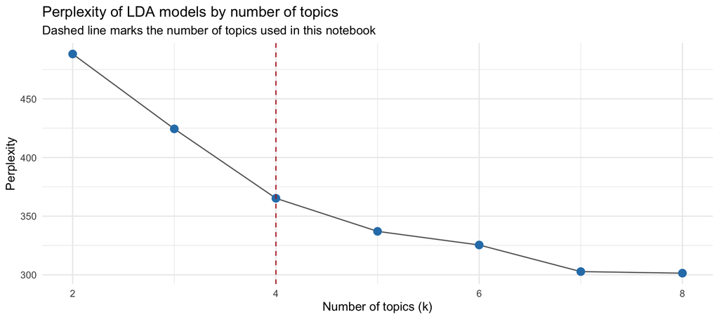

```r
k_grid <- 2:8
perp <- sapply(k_grid, function(k) {
  m <- LDA(dtm, k = k, method = "Gibbs", control = list(seed = 2026, iter = 1000, burnin = 200))
  perplexity(m, newdata = dtm, estimate_theta = FALSE)
})
ggplot(data.frame(k = k_grid, perplexity = perp), aes(k, perplexity)) +
  geom_line(colour = "grey40") + geom_point(size = 3, colour = "#2C7FB8") +
  geom_vline(xintercept = params$n_topics, linetype = "dashed", colour = "firebrick") +
  labs(title = "Perplexity of LDA models by number of topics",
       subtitle = "Dashed line marks the number of topics used in this notebook",
       x = "Number of topics (k)", y = "Perplexity") +
  theme_minimal()
```

## Fitting the model

```r
lda_model <- LDA(dtm, k = params$n_topics, method = "Gibbs",
                 control = list(seed = 2026, iter = 2000, burnin = 500, alpha = 0.1))

beta  <- tidy(lda_model, matrix = "beta")    # word distribution per topic
gamma <- tidy(lda_model, matrix = "gamma")   # topic distribution per document
```

## Top topics

Topics are ranked by prevalence, the average share of each topic across all documents. A short label is built from each topic’s three strongest words.

```r
top_terms <- beta %>%
  group_by(topic) %>%
  slice_max(beta, n = params$top_k, with_ties = FALSE) %>%
  arrange(topic, desc(beta)) %>%
  ungroup()

topic_labels <- top_terms %>%
  group_by(topic) %>%
  summarise(label = paste(head(term, 3), collapse = " / "))

topic_rank <- gamma %>%
  group_by(topic) %>%
  summarise(prevalence = mean(gamma)) %>%
  left_join(topic_labels, by = "topic") %>%
  arrange(desc(prevalence)) %>%
  mutate(rank = row_number(), prevalence = round(prevalence, 3))
topic_rank
```

| topic | prevalence | label | rank |
| --- | --- | --- | --- |
| 4 | 0.313 | service / invoice / department | 1 |
| 3 | 0.287 | police / cape / cold | 2 |
| 2 | 0.216 | department / priority / school | 3 |
| 1 | 0.184 | government / public / coalition | 4 |

## Top k words per topic with their word distribution

`beta` is the probability of a word given the topic. The cumulative column shows how much of the topic’s probability mass the top words cover.

```r
top_terms %>%
  group_by(topic) %>%
  mutate(beta = round(beta, 4),
         cumulative = round(cumsum(beta), 3),
         rank = row_number()) %>%
  ungroup() %>%
  select(topic, rank, term, beta, cumulative) %>%
  knitr::kable(caption = paste("Top", params$top_k, "words per topic and their probability"))
```

Top 10 words per topic and their probability

| topic | rank | term | beta | cumulative |
| --- | --- | --- | --- | --- |
| 1 | 1 | government | 0.0416 | 0.042 |
| 1 | 2 | public | 0.0330 | 0.075 |
| 1 | 3 | coalition | 0.0295 | 0.104 |
| 1 | 4 | administration | 0.0209 | 0.125 |
| 1 | 5 | country | 0.0192 | 0.144 |
| 1 | 6 | minister | 0.0140 | 0.158 |
| 1 | 7 | role | 0.0140 | 0.172 |
| 1 | 8 | governance | 0.0105 | 0.183 |
| 1 | 9 | policy | 0.0105 | 0.193 |
| 1 | 10 | relationship | 0.0105 | 0.204 |
| 2 | 1 | department | 0.0367 | 0.037 |
| 2 | 2 | priority | 0.0176 | 0.054 |
| 2 | 3 | school | 0.0141 | 0.068 |
| 2 | 4 | unemployment | 0.0141 | 0.082 |
| 2 | 5 | continue | 0.0124 | 0.095 |
| 2 | 6 | meth | 0.0124 | 0.107 |
| 2 | 7 | ensure | 0.0106 | 0.118 |
| 2 | 8 | report | 0.0106 | 0.128 |
| 2 | 9 | labour | 0.0106 | 0.139 |
| 2 | 10 | work | 0.0089 | 0.148 |
| 3 | 1 | police | 0.0215 | 0.021 |
| 3 | 2 | cape | 0.0157 | 0.037 |
| 3 | 3 | cold | 0.0157 | 0.053 |
| 3 | 4 | expect | 0.0138 | 0.067 |
| 3 | 5 | weather | 0.0138 | 0.080 |
| 3 | 6 | west | 0.0138 | 0.094 |
| 3 | 7 | western | 0.0138 | 0.108 |
| 3 | 8 | team | 0.0118 | 0.120 |
| 3 | 9 | sandf | 0.0118 | 0.132 |
| 3 | 10 | week | 0.0099 | 0.142 |
| 4 | 1 | service | 0.0328 | 0.033 |
| 4 | 2 | invoice | 0.0295 | 0.062 |
| 4 | 3 | department | 0.0214 | 0.084 |
| 4 | 4 | pay | 0.0214 | 0.105 |
| 4 | 5 | eskom | 0.0197 | 0.125 |
| 4 | 6 | day | 0.0197 | 0.144 |
| 4 | 7 | psc | 0.0197 | 0.164 |
| 4 | 8 | gxoyiya | 0.0165 | 0.181 |
| 4 | 9 | provider | 0.0148 | 0.195 |
| 4 | 10 | official | 0.0132 | 0.209 |

A wide view makes the topics easier to compare side by side:

```r
top_terms %>%
  group_by(topic) %>%
  mutate(rank = row_number(),
         word = paste0(term, " (", sprintf("%.3f", beta), ")")) %>%
  ungroup() %>%
  select(rank, topic, word) %>%
  pivot_wider(names_from = topic, values_from = word, names_prefix = "Topic ")
```

| rank | Topic 1 | Topic 2 | Topic 3 | Topic 4 |
| --- | --- | --- | --- | --- |
| 1 | government (0.042) | department (0.037) | police (0.022) | service (0.033) |
| 2 | public (0.033) | priority (0.018) | cape (0.016) | invoice (0.030) |
| 3 | coalition (0.030) | school (0.014) | cold (0.016) | department (0.021) |
| 4 | administration (0.021) | unemployment (0.014) | expect (0.014) | pay (0.021) |
| 5 | country (0.019) | continue (0.012) | weather (0.014) | eskom (0.020) |
| 6 | minister (0.014) | meth (0.012) | west (0.014) | day (0.020) |
| 7 | role (0.014) | ensure (0.011) | western (0.014) | psc (0.020) |
| 8 | governance (0.011) | report (0.011) | team (0.012) | gxoyiya (0.016) |
| 9 | policy (0.011) | labour (0.011) | sandf (0.012) | provider (0.015) |
| 10 | relationship (0.011) | work (0.009) | week (0.010) | official (0.013) |

## Topic distribution per document

```r
doc_topics <- gamma %>%
  mutate(gamma = round(gamma, 3)) %>%
  pivot_wider(names_from = topic, values_from = gamma, names_prefix = "T") %>%
  left_join(gamma %>% group_by(document) %>% slice_max(gamma, n = 1, with_ties = FALSE) %>%
              select(document, dominant_topic = topic), by = "document") %>%
  left_join(news_df %>% transmute(document = file_name,
                                  headline = str_trim(str_extract(content, "^[^\r\n]+"))),
            by = "document") %>%
  arrange(dominant_topic, document)
doc_topics
```

| document | T1 | T2 | T3 | T4 | dominant_topic | headline |
| --- | --- | --- | --- | --- | --- | --- |
| news_7.txt | 0.630 | 0.070 | 0.001 | 0.300 | 1 | Democratic dispensation necessitated a complete overhaul of state bureaucracy |
| news_8.txt | 0.917 | 0.083 | 0.000 | 0.000 | 1 | Trust and relationships key ingredients to coalition governments |
| news_2.txt | 0.001 | 0.998 | 0.001 | 0.001 | 2 | Gauteng Education commits to implementing Mayibuye Primary School remedial actions |
| news_3.txt | 0.171 | 0.828 | 0.000 | 0.000 | 2 | New Labour Minister charts the way forward |
| news_10.txt | 0.000 | 0.092 | 0.829 | 0.079 | 3 | Wet, cold weather expected to continue in Western Cape |
| news_4.txt | 0.001 | 0.001 | 0.988 | 0.010 | 3 | Police recue two kidnapped victims in Benoni |
| news_5.txt | 0.001 | 0.048 | 0.950 | 0.001 | 3 | President Ramaphosa sends condolences to deceased SANDF members |
| news_1.txt | 0.001 | 0.034 | 0.101 | 0.863 | 4 | Eskom former official, service provider appear in court |
| news_6.txt | 0.000 | 0.000 | 0.000 | 0.999 | 4 | Accounting officers must be accountable for non-payment of service providers |
| news_9.txt | 0.118 | 0.001 | 0.001 | 0.881 | 4 | PSC applauds officials who refuse to accept a bribes |

## Interpretation

The perplexity curve drops sharply up to k = 4 and then flattens, so 4 topics is the elbow and the model used here. Reading the top words and the documents that load on each topic gives these themes:

| Topic | Theme | Evidence from top words | Main articles |
| --- | --- | --- | --- |
| 1 | Coalition government and public administration | government, public, coalition, administration, governance, policy, relationship | news_8 (coalition webinar), news_7 (overhaul of state bureaucracy) |
| 2 | Education and labour priorities | department, priority, school, unemployment, labour, work | news_2 (Mayibuye Primary School), news_3 (new Labour Minister) |
| 3 | Public safety and weather alerts | police, cape, cold, weather, western, team, sandf | news_10 (Western Cape weather), news_4 (Benoni kidnapping), news_5 (SANDF condolences) |
| 4 | Service delivery and financial accountability | service, invoice, department, pay, eskom, psc, provider, official | news_1 (Eskom fraud case), news_6 (late payment of suppliers), news_9 (PSC on bribes) |

Most articles are dominated by a single topic with a gamma above 0.8, which shows the topics separate the corpus well. The clearest mixed case is news_7, which is about 63% Topic 1 and 30% Topic 4 because it discusses bureaucracy reform and accountability of officials together. Topic 4 is the most prevalent theme, which fits a government news feed where three of the ten stories deal with how public money is handled. The beta values are small (the strongest word in each topic sits around 0.02 to 0.04) because the vocabulary has 875 terms spread over only 10 short documents. That is normal for LDA on a small corpus, and the ranking of words matters more than their absolute size.

# 2.3 Visualising the top words in each topic

## Method 1: Bar chart of word probabilities

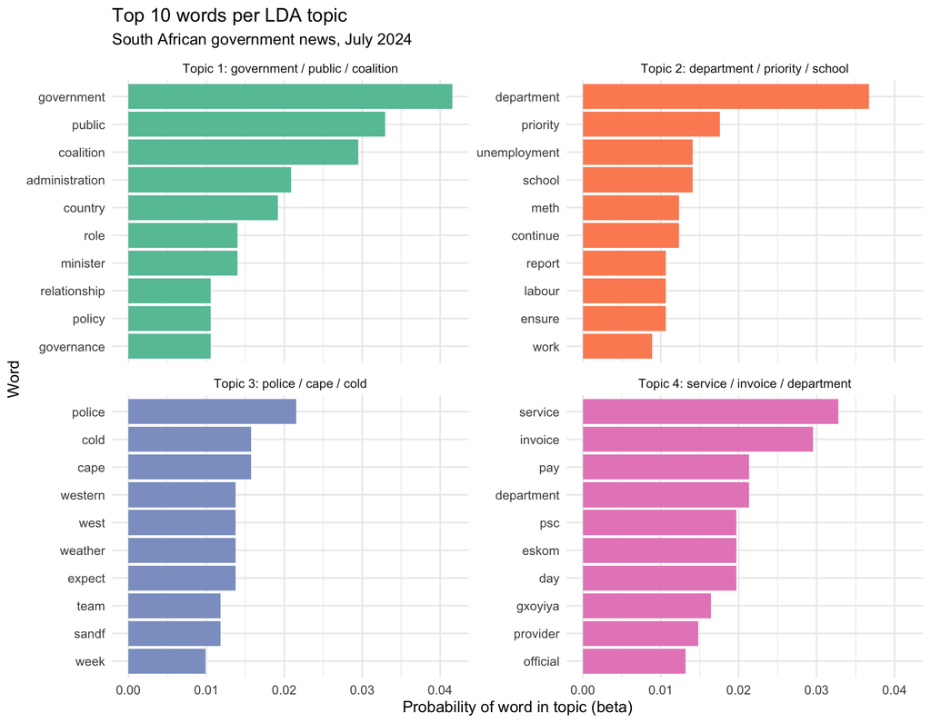

```r
top_terms %>%
  left_join(topic_labels, by = "topic") %>%
  mutate(panel = paste0("Topic ", topic, ": ", label),
         term = reorder_within(term, beta, panel)) %>%
  ggplot(aes(beta, term, fill = factor(topic))) +
  geom_col(show.legend = FALSE) +
  facet_wrap(~ panel, scales = "free_y") +
  scale_y_reordered() +
  scale_fill_brewer(palette = "Set2") +
  labs(title = paste("Top", params$top_k, "words per LDA topic"),
       subtitle = "South African government news, July 2024",
       x = "Probability of word in topic (beta)", y = "Word") +
  theme_minimal(base_size = 11)
```

## Method 2: Word cloud per topic

Word size is proportional to beta, so the biggest words carry the most weight in the topic.

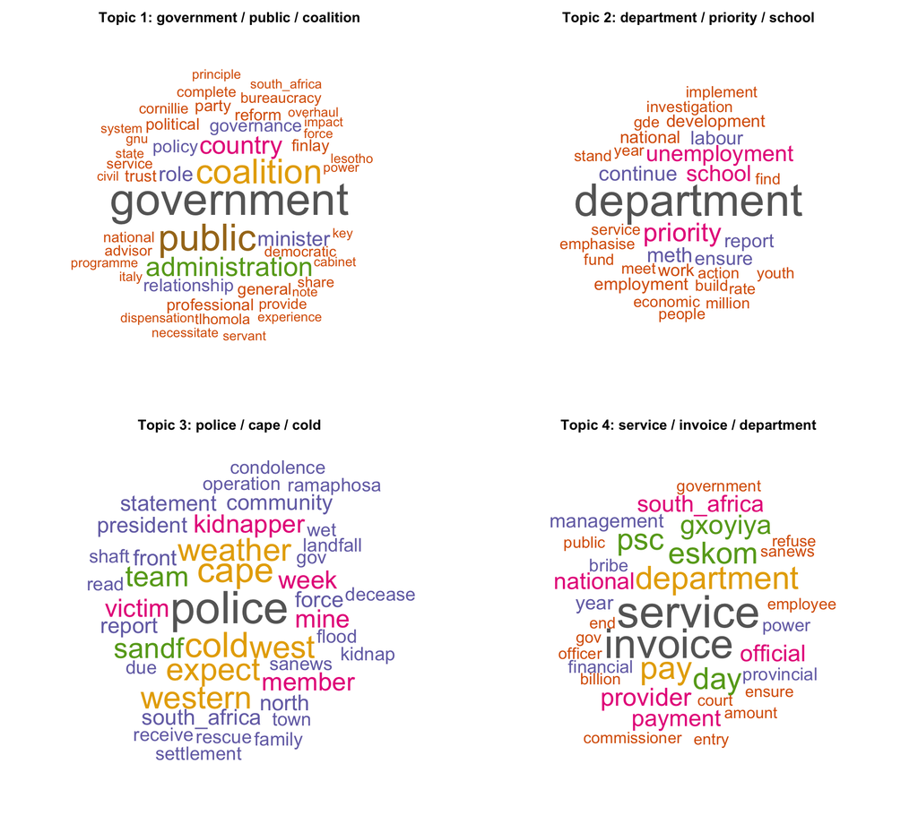

```r
pal <- brewer.pal(8, "Dark2")
n <- params$n_topics
par(mfrow = c(ceiling(n / 2), 2), mar = c(0, 0, 2, 0))
for (t in seq_len(n)) {
  d <- beta %>% filter(topic == t) %>% slice_max(beta, n = 30)
  wordcloud(d$term, d$beta, scale = c(3.2, 0.6), random.order = FALSE,
            rot.per = 0, colors = pal)
  title(main = paste0("Topic ", t, ": ", topic_labels$label[t]), cex.main = 1)
}
```

## Method 3: Heat map of word weights across topics

The heat map shows the same top words against every topic, which makes overlap between topics visible.

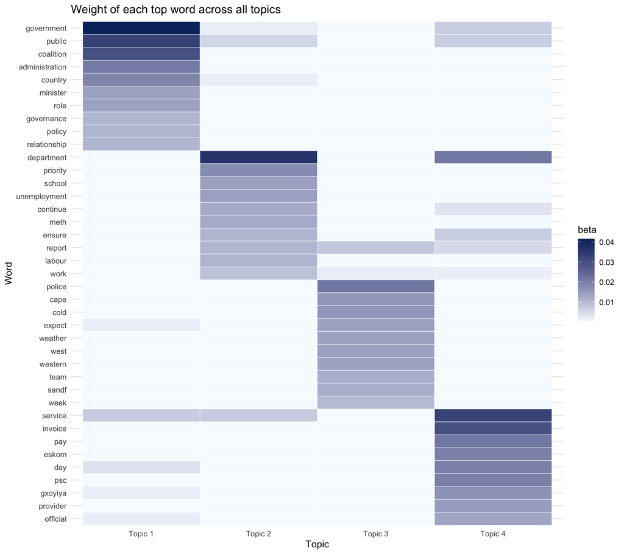

```r
heat_terms <- unique(top_terms$term)
beta %>%
  filter(term %in% heat_terms) %>%
  mutate(topic = paste("Topic", topic),
         term = factor(term, levels = rev(heat_terms))) %>%
  ggplot(aes(topic, term, fill = beta)) +
  geom_tile(colour = "white") +
  scale_fill_gradient(low = "#F7FBFF", high = "#08306B", name = "beta") +
  labs(title = "Weight of each top word across all topics",
       x = "Topic", y = "Word") +
  theme_minimal(base_size = 10)
```

## Document to topic heat map

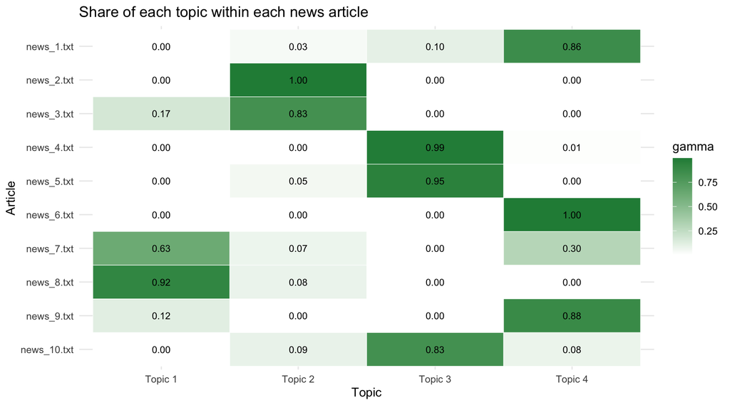

```r
gamma %>%
  mutate(topic = paste("Topic", topic),
         document = factor(document, levels = rev(news_df$file_name))) %>%
  ggplot(aes(topic, document, fill = gamma)) +
  geom_tile(colour = "white") +
  geom_text(aes(label = sprintf("%.2f", gamma)), size = 3) +
  scale_fill_gradient(low = "white", high = "#238B45", name = "gamma") +
  labs(title = "Share of each topic within each news article",
       x = "Topic", y = "Article") +
  theme_minimal()
```